# Covid-19 spread and its affect on different countries/regions

#### S Sri Manish Goud , IIT Gandhinagar, srimanishgoud_s@iitgn.ac.in Voorugonda Rajesh , IIT Gandhinagar, voorugonda.rajesh@iitgn.ac.in Siva Sai Bommisetty , IIT Gandhinagar, bommisetty.siva@iitgn.ac.in Venkata Sriman Narayana Malli , IIT Gandhinagar, venkata.sriman@iitgn.ac.in

### Introduction

The COVID-19 pandemic has caused significant disruptions to daily life around the world since it was first identified in Wuhan, China, on December 2019. The pandemic has had an impact not only on people's daily lives but also on economies, education systems, and healthcare systems worldwide, leading to widespread lockdowns, travel restrictions, and vaccination efforts. The virus has spread rapidly, affecting millions of people and causing hundreds of thousands of deaths. More than 200 million positive cases and 4 million deaths were reported globally. So, it is essential for us to understand how the virus spreads and impacts different regions and countries.

We analyze COVID-19 spread using the data which Governments across the globe and World Health Organization(WHO) maintain.

```python
# Importing libraries
import pandas as pd
import numpy as np
import matplotlib.pyplot as plt

from datetime import datetime  # for datetime calculations

# import plotly
import plotly.graph_objects as go
import plotly.express as px
import plotly.io as pio

import requests

import plotly.graph_objects as go
from plotly.subplots import make_subplots
```

## World-wise Analysis

### Importing Dataset

Let us take the dataset from [WHO](https://covid19.who.int/data) which contains the data about the cumulative number of cases and deaths along with new deaths and cases for each day starting from January 3rd 2020 to April 26th 2023, that is the data of around 1210 days.

```python
df = pd.read_csv('data/WHO-COVID-19-global-data.csv')
```

```python
# Convert str to date object
df['Date_reported'] = pd.to_datetime(df['Date_reported'])
```

```python
df.head()
```

|  | Date_reported | Country_code | Country | WHO_region | New_cases | Cumulative_cases | New_deaths | Cumulative_deaths |
| --- | --- | --- | --- | --- | --- | --- | --- | --- |
| 0 | 2020-01-03 | AF | Afghanistan | EMRO | 0 | 0 | 0 | 0 |
| 1 | 2020-01-04 | AF | Afghanistan | EMRO | 0 | 0 | 0 | 0 |
| 2 | 2020-01-05 | AF | Afghanistan | EMRO | 0 | 0 | 0 | 0 |
| 3 | 2020-01-06 | AF | Afghanistan | EMRO | 0 | 0 | 0 | 0 |
| 4 | 2020-01-07 | AF | Afghanistan | EMRO | 0 | 0 | 0 | 0 |

```python
df.info()
```

```
<class 'pandas.core.frame.DataFrame'>
RangeIndex: 286770 entries, 0 to 286769
Data columns (total 8 columns):
 #   Column             Non-Null Count   Dtype
---  ------             --------------   -----
 0   Date_reported      286770 non-null  datetime64[ns]
 1   Country_code       285560 non-null  object
 2   Country            286770 non-null  object
 3   WHO_region         286770 non-null  object
 4   New_cases          286770 non-null  int64
 5   Cumulative_cases   286770 non-null  int64
 6   New_deaths         286770 non-null  int64
 7   Cumulative_deaths  286770 non-null  int64
dtypes: datetime64[ns](1), int64(4), object(3)
memory usage: 17.5+ MB
```

```python
# Number of unique countries
print(f"Number of countries: {df.Country.unique().shape[0]}")
```

```
Number of countries: 237
```

```python
# time range
print("External Data")
print(f"Earliest Entry: {df['Date_reported'].min().date()}")
print(f"Last Entry:     {df['Date_reported'].max().date()}")
# Get the number of days between the first and last entry
print(
    f"Total Days:     {(df['Date_reported'].max() - df['Date_reported'].min()).days + 1} days")
```

```
External Data
Earliest Entry: 2020-01-03
Last Entry:     2023-04-26
Total Days:     1210 days
```

### Cumulative cases of top 40 countries

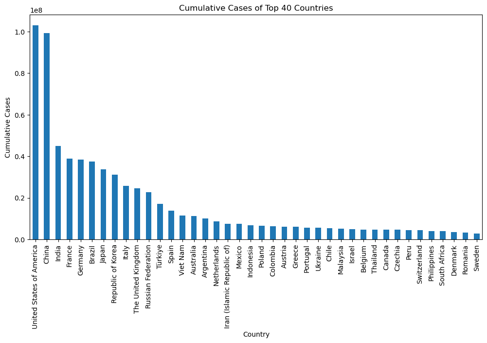

```python
cumulative_cases = df["Cumulative_cases"].groupby(df['Country']).max()
# plot bar chart of cumulative cases of few countries
cumulative_cases.nlargest(40).plot(kind='bar', figsize=(
    12, 6), title="Cumulative Cases of Top 40 Countries")
plt.ylabel("Cumulative Cases")
plt.show()
```

The bar plot above shows cumulative cases of the top 40 countries. We can see that the United States, China, India, France, Germany, Brazil, Japan, Korea, Italy, UK topped the list. It is surprising that except for India and Brazil remaining, all others are developed countries. Despite being forward in both economic and technological terms, it seems that these developed countries couldn't control the pandemic outbreak.

### Cumulative deaths of top 40 countries

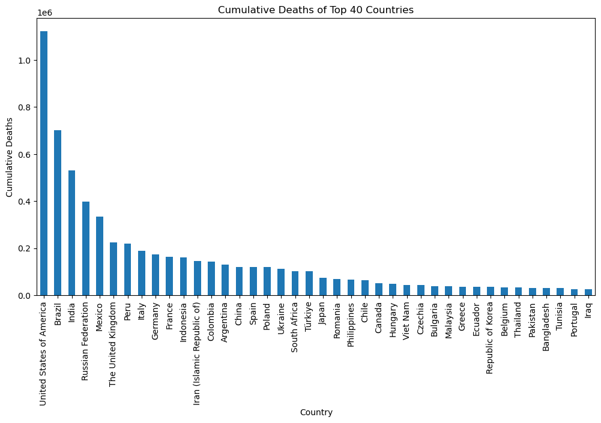

```python
# plot bar chart of cumulative deaths of top 40 countries
cumulative_deaths = df["Cumulative_deaths"].groupby(df['Country']).max()
cumulative_deaths.nlargest(40).plot(kind='bar', figsize=(
    12, 6), title="Cumulative Deaths of Top 40 Countries")
plt.ylabel("Cumulative Deaths")
plt.show()
```

### Death ratio of top 40 countries

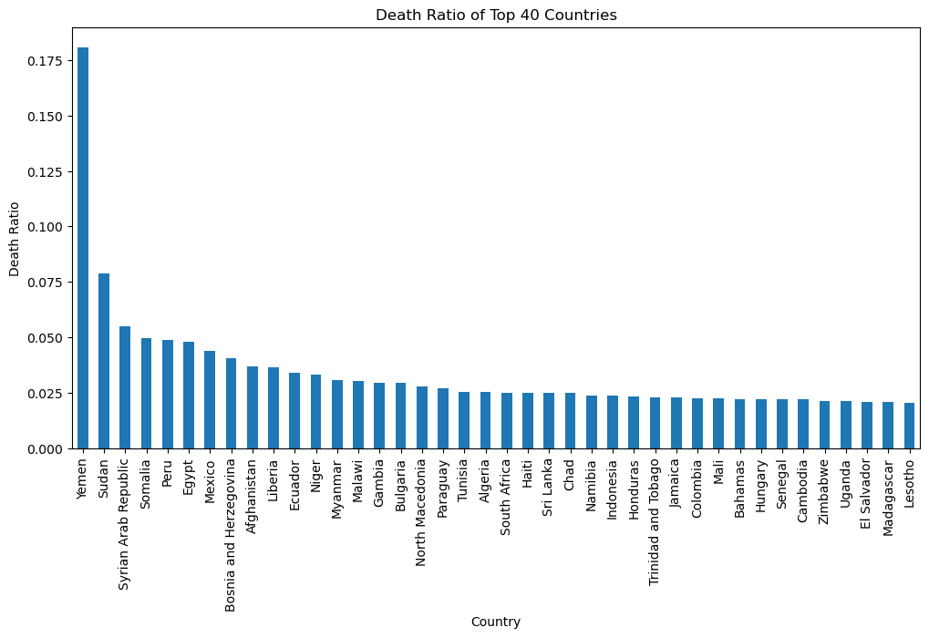

```python
# Plot the death ratios of top 40 countries as per cumulative cases
death_ratio = cumulative_deaths / cumulative_cases
death_ratio.nlargest(40).plot(kind='bar', figsize=(
    12, 6), title="Death Ratio of Top 40 Countries")
plt.ylabel("Death Ratio")
plt.show()
```

### Observing the trend in daily cases and daily deaths in India

```python
data = df[df["Country"] == "India"]
```

```python
# plot daily cases in India
fig = px.bar(data, x='Date_reported', y='New_cases',
             title="Daily Cases in India", labels={"Date_reported":"Date", "New_cases":"cases"})
fig.show()
```

```python
# plot daily deaths in India
fig = px.bar(data, x='Date_reported', y='New_deaths',
             title="Daily deaths in India", labels={'Date_reported': "Date", "New_deaths": 'New deaths'})
fig.show()
```

Now, let us have a look at the number of new deaths and new cases per day in India over the span of three years. The above plots indicate three significant outbreaks of COVID-19 in India, one each in 2020, 2021, 2022. It is interesting to see that each time when people thought that everything was under control, a new wave began and ruined their hopes. From the plots, it is evident that the outbreak in 2021 is more severe than the one in 2020; however, the most impacting one(2021) didn't last long compared to the less impacting one(2020). If we remember, these are the two time zones where we had our lockdowns. We can also see that there is a peak in the number of new cases in Januray-February 2022, but it isn't that significant in terms of the number of deaths per day.

### Cumulative deaths heatmap on world map

The plot below shows the cumulative deaths of all the countries worldwide. From the plot, we can see that from January 2020-December 2021, the number of deaths is increasing more in the USA, South American countries, India and Russia. It is interesting to see that the number of deaths in China isn't that much in the whole span of 2 years when compared to the rest of the world; also, from the plots, we can see that except for South Africa, none of the African countries seems to have been much affected from the pandemic.

```python
df = pd.read_csv('data/WHO-COVID-19-global-data.csv')

data = df[df['Date_reported'] >= '2020-01-01']

# plot the cases heatmap on the world map with date slider
fig = px.choropleth(data, locations="Country", locationmode='country names',
                    color="Cumulative_deaths", hover_name="Country",
                    animation_frame="Date_reported", title='Cumulative deaths from 2020-01-01',
                    color_continuous_scale=px.colors.sequential.Plasma, range_color=(min(data.Cumulative_deaths), max(data.Cumulative_deaths)))
fig.show()
```

### Cumulative cases heatmap on world map

The plot below shows the cumulative cases of all the countries worldwide. From the plot we can see that from January 2020-Decenmber 2021, the number of cases is increasing more in the USA, South American countries, India, and Russia. Interestingly, the number of cases in China isn't that much in the whole span of 2 years compared to the rest of the world; however, the cases seem to have increased in the last five months(December 2022-April 2023). Also, from the plots, we can see that, except for South Africa, none of the African countries seems to have been affected by the pandemic in this scenario too.

```python
# plot the cases heatmap on the world map with date slider
fig = px.choropleth(data, locations="Country", locationmode='country names',
                    color="Cumulative_cases", hover_name="Country",
                    animation_frame="Date_reported", title='Cumulative cases from 2020-01-01',
                    color_continuous_scale=px.colors.sequential.Plasma, range_color=(min(data.Cumulative_cases), max(data.Cumulative_cases)))
fig.show()
```

### New cases heatmap on world map

The following plot describes the new cases per day for every country from January 2020 - April 2023. We can use the slider to see which country has how many new cases on a particular day. This plot helps us understand which country is going through a covid wave in a particular period of time. We can access the number of new covid cases in a country on a particular day by hovering over that country.

For example, we can see that India has the highest number of covid cases per day in March-May 2021, which is the period when the second wave hit the Indian subcontinent.

```python
# plot the active cases heatmap on the world map with date slider
fig = px.choropleth(data, locations="Country", locationmode='country names',
                    color="New_cases", hover_name="Country",
                    animation_frame="Date_reported", title='New cases from 2020-01-01',
                    color_continuous_scale=px.colors.sequential.Plasma, range_color=(0, 10000))
fig.show()
```

From the above new cases world map, we can see that the number of new cases in China increased and decreased (after that remained low for around nine months) in January-April 2020, while in all remaining other countries, the number of new cases per day is more or less increasing continuously.

To analyse it better let us compare new cases per day in India, China, and USA in January-July 2020.

```python
# plot new cases for china, India, USA from 2020-01-01 to 2020-07-01
data = df[df['Date_reported'] >=
          '2020-01-01'][df['Date_reported'] <= '2020-07-01']
temp_data = data[data['Country'].isin(
    ['China', 'India', 'United States of America'])]
fig = px.line(temp_data, x='Date_reported', y='New_cases', color='Country',
              title='New cases for china, India, USA from 2020-01-01 to 2020-07-01',
             labels={'Date_reported':'Date', 'New_cases':'New cases'})
fig.show()
```

The plot clearly depicts the trend in the number of new cases in China, India and the USA, as discussed previously. We can see that initially the cases rose in China, and during that time the rest of the world was calm. But in around March when the situation in China was controlled, new cases started rising continuously in the rest of the countries. For example, the plot above shows the rapid case increase in India and the USA. The spread could be due to the traveling of Chinese people from China to other parts of the world.

```python
# plot cumulative cases for china, India, USA from 2020-01-01 to 2020-07-01
data = df[df['Date_reported'] >=
          '2020-01-01']
temp_data = data[data['Country'].isin(
    ['China', 'India', 'United States of America'])]
fig = px.line(temp_data, x='Date_reported', y='Cumulative_cases', color='Country',
              title='Cumulative cases for china, India, USA from 2020-01-01 to 2020-07-01', log_y=True,
             labels={'Date_reported':'Date', 'Cumulative_cases': 'cases'})
fig.show()
```

The plot tells us that the growth pattern of cases in the USA and India is almost similar.

> The pandemic affected people and countries not only in terms of human loss but also in terms of economy, trade, and employment rate. Let us look at these factors and how they affect different countries.

### Comparing changes in GDP

GDP, or Gross Domestic Product, is a measure of a country's economic activity and productivity. It is the total value of all goods and services produced within a country's borders during a specific period, typically a year. GDP is a vital indicator of a country's economic health and is often used to compare the financial performance of different countries. So, we use GDP to analyze the effect of COVID-19 on the country's economies.

We first import a dataset from International Monetary Fund's(IMF) world economic outlook database.

```python
# load the data from the GDP excel file
df = pd.read_csv('data/GDP.csv', encoding="ISO-8859-1")
```

```python
df.drop(['Scale', 'Estimates Start After', 'Units'], axis=1, inplace=True)
df.index = df['Country']
df.drop(['Country'], axis=1, inplace=True)
df.dropna(inplace=True)
```

```python
# convert the GDP to float
df["2017"] = df["2017"].str.replace(',', '').astype(float)
df["2018"] = df["2018"].str.replace(',', '').astype(float)
df["2019"] = df["2019"].str.replace(',', '').astype(float)
df["2020"] = df["2020"].str.replace(',', '').astype(float)
df["2021"] = df["2021"].str.replace(',', '').astype(float)
df["2022"] = df["2022"].str.replace(',', '').astype(float)
```

```python
# calculate the relative change in GDP for each year by modifying the dataframe
df['2022'] = (df['2022'] - df['2021'])/df['2021']
df['2021'] = (df['2021'] - df['2020'])/df['2020']
df['2020'] = (df['2020'] - df['2019'])/df['2019']
df['2019'] = (df['2019'] - df['2018'])/df['2018']
df['2018'] = (df['2018'] - df['2017'])/df['2017']

# Drop the first row as it is not required
df.drop(['2017'], axis=1, inplace=True)

df = df.T
```

```python
# plot the GDP of Canada, Japan, Norway, UK, Australia, France with log scale
fig = go.Figure()
fig.add_trace(go.Scatter(x=df.index, y=df['Canada'], name='Canada'))
fig.add_trace(go.Scatter(x=df.index, y=df['Japan'], name='Japan'))
fig.add_trace(go.Scatter(x=df.index, y=df['Norway'], name='Norway'))
fig.add_trace(go.Scatter(x=df.index, y=df['United Kingdom'], name='UK'))
fig.add_trace(go.Scatter(x=df.index, y=df['Australia'], name='Australia'))
fig.add_trace(go.Scatter(x=df.index, y=df['France'], name='France'))
fig.update_layout(title='Relative change in GDP of Canada, Japan, Norway, UK, Australia, France',
                  xaxis_title='Year', yaxis_title='Relative Change in GDP')
fig.show()
```

Here we analyze the effect of COVID-19 on developed countries such as Canada, Japan, Norway, the UK, Australia, and France. The above plot shows the relative changes in the GDP over the years of these countries. We know that productivity decreased during the pandemic because of the lockdown, and hence a country's GDP should decrease. The above plot shows that every country's GDP is falling in the year 2020, which supports our hypothesis. However, it is interesting to see that all of these countries' GDP increased in the following year(2021), which signifies that they understood the trend and might have changed how they worked, leading to a rapid increase.

```python
# plot the GDP of Canada, Norway, UK, Angola, India, China with log scale
fig = go.Figure()
fig.add_trace(go.Scatter(x=df.index, y=df['Australia'], name='Australia'))
fig.add_trace(go.Scatter(x=df.index, y=df['France'], name='France'))
fig.add_trace(go.Scatter(x=df.index, y=df['United Kingdom'], name='UK'))
fig.add_trace(go.Scatter(x=df.index, y=df['South Africa'], name='SA'))
fig.add_trace(go.Scatter(x=df.index, y=df['Thailand'], name='Thailand'))
fig.add_trace(go.Scatter(x=df.index, y=df['China'], name='China'))
fig.add_trace(go.Scatter(x=df.index, y=df['India'], name='India'))
fig.update_layout(title='GDP of Canada, Norway, UK, Angola, India, China',
                  xaxis_title='Year', yaxis_title='GDP')
fig.show()
```

Now let us look at how COVID-19 affected developed and developing countries. From the plot, it is clear that South Africa, India, and Thailand, the developing countries have a more significant relative change in 2020, while developed countries like Australia, the UK, China, and France have significantly less change. This signifies that COVID-19 has had a more significant impact on developing countries' economies than on developed countries' economies, which is a massive shock for developing countries.

### Changes in unemployment

The COVID-19 pandemic has significantly impacted the global economy, and one of the most visible effects has been on the unemployment rate. The pandemic has led to a widespread economic slowdown, causing many businesses to shut down or reduce their operations, resulting in a significant increase in unemployment.

In many countries, governments have implemented measures such as lockdowns and social distancing to slow the spread of the virus. These measures have forced many businesses to close or reduce their operations, resulting in job losses. In addition, many industries, such as travel, hospitality, and entertainment, have been particularly hard hit by the pandemic, leading to further job losses.

According to the International Labour Organization (ILO), the global unemployment rate increased from 4.4% in 2019 to 6% in 2020, resulting in an estimated 255 million full-time jobs lost worldwide.

Now let us have a look at the unemployment rate in 2020(major breakout across the world) of several countries using the dataset from International Monetary Fund's(IMF) World Economic Outlook database.

```python
df = pd.read_csv('data/Unemployment_data.csv', encoding="ISO-8859-1")
```

```python
df.drop(['Scale', 'Estimates Start After', 'Units'], axis=1, inplace=True)
df.index = df['Country']
df.drop(['Country'], axis=1, inplace=True)
df.dropna(inplace=True)
```

```python
# convert the unemployment to float
df["2017"] = df["2017"].replace(',', '').astype(float)
df["2018"] = df["2018"].replace(',', '').astype(float)
df["2019"] = df["2019"].replace(',', '').astype(float)
df["2020"] = df["2020"].replace(',', '').astype(float)
df["2021"] = df["2021"].replace(',', '').astype(float)
df["2022"] = df["2022"].replace(',', '').astype(float)
```

```python
df = df.T
```

```python
# plot the GDP of Canada, Norway, UK, Angola, India, China with log scale
fig = go.Figure()
fig.add_trace(go.Scatter(x=df.index, y=df['Malaysia'], name='Malaysia'))
fig.add_trace(go.Scatter(x=df.index, y=df['Brazil'], name='Brazil'))
fig.add_trace(go.Scatter(x=df.index, y=df['United Kingdom'], name='UK'))
fig.add_trace(go.Scatter(x=df.index, y=df['South Africa'], name='SA'))
fig.add_trace(go.Scatter(x=df.index, y=df['Thailand'], name='Thailand'))
fig.add_trace(go.Scatter(x=df.index, y=df['China'], name='China'))
fig.add_trace(go.Scatter(x=df.index, y=df['Sri Lanka'], name='Sri Lanka'))
fig.update_layout(title='GDP of Malaysia, Brazil, UK, South Africa, Thailand, China, Sri Lanka',
                  xaxis_title='Year', yaxis_title='GDP')
fig.show()
```

The above plot shows the unemployment rate of Malaysia, Brazil, the UK, SA, Thailand, China, and Sri Lanka over several years. From the plot, we can see that the unemployment rate increased in the year 2020 for every country; the trend continued afterwards also in some countries like Malaysia and South Africa.

An important observation is that every country's unemployment rate has increased, irrespective of whether it is developed or developing.

# Indian Statewise Analysis

###### Scraping data from https://www.mygov.in/covid-19

```python
from selenium import webdriver
from selenium.webdriver.chrome.options import Options
from bs4 import BeautifulSoup
from selenium.webdriver.common.by import By

# Set up the headless browser
chrome_options = Options()
chrome_options.add_argument('--headless')
driver = webdriver.Chrome(options=chrome_options)

# Navigate to the URL
url = 'https://www.mygov.in/covid-19'
driver.get(url)

# Wait for the table to load
driver.implicitly_wait(1)

# Parse the HTML code of the table using BeautifulSoup
soup = BeautifulSoup(driver.page_source, 'lxml')

# Quit the headless browser
driver.quit()

# Find the table
table = soup.find('table', {'id': 'ind_mp_tbl'})
# Extract the table headers
headers = [header.text for header in table.find_all('th')]

# Extract the table rows
rows = []
for row in table.find_all('tr'):
    rows.append([])
    for col in row.find_all('td'):
        # remove the span tag from the col
        for span in col.select('span'):
            span.extract()
        # add the col to the row
        rows[-1].append(col.text)

# Convert the rows into a dataframe
df = pd.DataFrame(rows, columns=headers)
df.dropna(inplace=True)
```

```python
# Convert the data types of the columns
df['Total Cases'] = df['Total Cases'].apply(lambda x: x.replace(',', ''))
df['Total Cases'] = df['Total Cases'].astype(np.int64)
df['Active'] = df['Active'].apply(lambda x: x.replace(',', ''))
df["Active"] = df["Active"].astype(np.int64)
df['Discharged'] = df['Discharged'].apply(lambda x: x.replace(',', ''))
df["Discharged"] = df["Discharged"].astype(np.int64)
df['Deaths'] = df['Deaths'].apply(lambda x: x.replace(',', ''))
df["Deaths"] = df["Deaths"].astype(np.int64)
df["Active Ratio"] = df["Active Ratio"].apply(lambda x: x.replace('%', ''))
df["Active Ratio"] = df["Active Ratio"].astype(float)
df["Discharge Ratio"] = df["Discharge Ratio"].apply(
    lambda x: x.replace('%', ''))
df["Discharge Ratio"] = df["Discharge Ratio"].astype(float)
df["Death Ratio"] = df["Death Ratio"].apply(lambda x: x.replace('%', ''))
df["Death Ratio"] = df["Death Ratio"].astype(float)
```

```python
df.head()
```

|  | State/UTs | Total Cases | Active | Discharged | Deaths | Active Ratio | Discharge Ratio | Death Ratio |
| --- | --- | --- | --- | --- | --- | --- | --- | --- |
| 1 | Maharashtra | 8165466 | 4079 | 8012873 | 148514 | 0.05 | 98.13 | 1.82 |
| 2 | Kerala | 6894588 | 11123 | 6811640 | 71825 | 0.16 | 98.80 | 1.04 |
| 3 | Karnataka | 4086300 | 1407 | 4044545 | 40348 | 0.03 | 98.98 | 0.99 |
| 4 | Tamil Nadu | 3608321 | 2928 | 3567325 | 38068 | 0.08 | 98.86 | 1.06 |
| 5 | Andhra Pradesh | 2340533 | 222 | 2325578 | 14733 | 0.01 | 99.36 | 0.63 |

```python
cumulative_active = df['Active'].sum()/df['Total Cases'].sum()
cumulative_deaths = df['Deaths'].sum()/df['Total Cases'].sum()
cumulative_discharged = df['Discharged'].sum()/df['Total Cases'].sum()

print('Cumulative Active Ratio: {:.2f}%'.format(cumulative_active*100))
print('Cumulative Death Ratio: {:.2f}%'.format(cumulative_deaths*100))
print('Cumulative Discharge Ratio: {:.2f}%'.format(cumulative_discharged*100))
```

```
Cumulative Active Ratio: 0.11%
Cumulative Death Ratio: 1.18%
Cumulative Discharge Ratio: 98.71%
```

1. The above table depicts the total cases, total active cases, and deaths in Indian states per mygov.in website.
2. The total number of deaths in India is disappointing, but the cumulative discharge ratio is far better than the cumulative death ratio.
3. So, we can say India has a fair amount of hospital facilities.

### Top 10 states with maximum confirmed cases

```python
# historgram of top 10 states with maximum confirmed cases
fig = px.histogram(df.nlargest(10, "Total Cases"),
                   x="State/UTs", y="Total Cases", title="Confirmed Cases")
fig.show()
```

### Top 10 states with maximum deaths

```python
# historgram of top 10 states with maximum Deaths
fig = px.histogram(df.nlargest(10, "Deaths"), x="State/UTs",
                   y="Deaths", title="Deaths")
fig.show()
```

1. Maharashtra has been the hardest-hit state in India in terms of COVID-19 deaths. The state has reported a significantly higher number of deaths compared to other states in India.
2. The top 10 states are spatially located in different regions of India, indicating that the pandemic has affected the entire country.
3. States with large population densities, such as Uttar Pradesh, West Bengal, and Andhra Pradesh, are among the top 10 states regarding cumulative deaths, suggesting that population density may have played a role in the spread of the virus.
4. States like Maharashtra(Mumbai), Karnataka(Bangalore), Tamil Nadu(Chennai), and Delhi have large urban centers, so there is a higher risk due to factors such as population density, more frequent travel, and greater reliance on public transportation.

> Both the top 10 states for total deaths and total cases are similar, implying high correlation between them, in states having high number of cases.

### Top 10 states with maximum death ratios

```python
# historgram of top 10 states with maximum death ratios
fig = px.histogram(df.nlargest(10, "Death Ratio"),
                   x="State/UTs", y="Death Ratio", title="Death Ratio")
fig.show()
```

```python
# Total cases in Punjab, Nagaland
punjab_cases = df[df['State/UTs'] == 'Punjab']['Total Cases'].values[0]
nagaland_cases = df[df['State/UTs'] == 'Nagaland']['Total Cases'].values[0]
print('Total cases in Punjab: {}'.format(punjab_cases))
print('Total cases in Nagaland: {}'.format(nagaland_cases))
```

```
Total cases in Punjab: 790879
Total cases in Nagaland: 36002
```

1. Although states like Punjab, Nagaland, etc., have less number of cases, their death ratio is much higher.
2. This might be due to poor hospitalized conditions or lack of amenities.
3. Maharashtra has the highest number of cases and deaths, and also death ratio is also higher.
4. The emergence of more variants of COVID-19, such as the Delta variant, may have contributed to higher death ratios in some states. For example, Maharashtra was one of the first states to report cases of the Delta variant(which may be absent in other states), which may have contributed to its high death ratio.

###### Extracting state population and area

```python
# Make a GET request to the Wikipedia page
url = 'https://en.wikipedia.org/wiki/Demographics_of_India'
response = requests.get(url)

# Parse the HTML content using BeautifulSoup
soup = BeautifulSoup(response.text, 'html.parser')

# Find the table containing the state-wise population and area data
table = None
for t in soup.find_all('table', {'class': 'wikitable sortable'}):
    headers = [th.text.strip() for th in t.find_all('th')]
    if 'State/UT' in headers and 'Population[48]' in headers and 'Area[50] (km2)' in headers:
        table = t
        break

# Extract the data from the table and store it in a pandas DataFrame
data = []
for row in table.find_all('tr')[1:]:
    columns = row.find_all('td')
    if len(columns) == 0:
        continue
    state = columns[1].text.strip()
    if "(UT)" in state:
        state = state[:-5]
    population = int(columns[2].text.strip().replace(',', ''))
    area = float(columns[10].text.strip().replace(',', ''))
    data.append({'State/UTs': state, 'Population': population, 'Area': area})
population_area_df = pd.DataFrame(data)
```

```python
# Merge the population and area data with the COVID-19 cases data
df = pd.merge(df, population_area_df, on='State/UTs')
```

```python
df.head()
```

|  | State/UTs | Total Cases | Active | Discharged | Deaths | Active Ratio | Discharge Ratio | Death Ratio | Population | Area |
| --- | --- | --- | --- | --- | --- | --- | --- | --- | --- | --- |
| 0 | Maharashtra | 8165466 | 4079 | 8012873 | 148514 | 0.05 | 98.13 | 1.82 | 112374333 | 307713.0 |
| 1 | Kerala | 6894588 | 11123 | 6811640 | 71825 | 0.16 | 98.80 | 1.04 | 33406061 | 38863.0 |
| 2 | Karnataka | 4086300 | 1407 | 4044545 | 40348 | 0.03 | 98.98 | 0.99 | 61095297 | 191791.0 |
| 3 | Tamil Nadu | 3608321 | 2928 | 3567325 | 38068 | 0.08 | 98.86 | 1.06 | 72147030 | 130058.0 |
| 4 | Andhra Pradesh | 2340533 | 222 | 2325578 | 14733 | 0.01 | 99.36 | 0.63 | 49386799 | 160205.0 |

### Cumulative cases(per million population)

```python
# Plotting cumulative cases per million population(average)
df['Cases per million'] = df['Total Cases'] / df['Population'] * 1000000
fig = px.bar(df, x='State/UTs', y='Cases per million',
             title='Cases per million population')
fig.show()
```

Here we can see that the spread of the virus in Maharashtra is not that bad even though it accounts for most confirmed cases and deaths. The spread is only 75K per 1 million people; the confirmed cases and deaths are more because of the comparatively high population of Maharashtra. From the plot, it is clear that the spread is more in Kerala, Goa, Mizoram, Delhi, Puducherry, Chandigarh, etc. Hence actions need to be taken in these states to control the spread.

### Cumulative cases(per 100 sq-km area)

```python
# Plotting cumulative cases per 100 sq km area(average) with log scale
df['Cases per 100 sq km area'] = df['Total Cases'] / df['Area'] * 100
fig = px.bar(df, x='State/UTs', y='Cases per 100 sq km area',
             title='Cases per 100 sq km area', log_y=True)
fig.show()
```

The above plot shows the number of confirmed cases per 100 square KM of the state. We can see that the number of cases per area is more in Kerala, Delhi, Goa, Puducherry, and Chandigarh, indicating that within a given area of 100 square KM, there are more cases in these states. Hence these states are at more risk and have the most chance of fast spreading; necessary care and measures are needed in these states to stop a severe outbreak.

Another important point to note here is that the number of confirmed cases per 100 Km-sq and the number of confirmed cases per 1 Million people give similar insights that Kerala, Delhi, Goa, Puducherry, and Chandigarh are at high risk. Hence we can say that these measures are more accurate than simply looking at the number of cases and deaths.

## Conclusion

The COVID-19 pandemic has had a profound impact on nearly every aspect of our lives. From the way we work and socialize to the way we access healthcare and education, the pandemic has forced us to adapt to new ways of living and interacting with each other.

As we have seen through this assignment, the pandemic has not affected all countries and regions equally. Some countries with strong healthcare systems and effective government responses were able to contain the spread of the virus and minimize the impact on their populations. Other countries, particularly those with weaker healthcare infrastructure or less coordinated government responses, have experienced more severe outbreaks and higher death tolls. One of the most significant challenges of the pandemic has been the global nature of the outbreak. The virus knows no borders, and its spread has highlighted the interconnectedness of our world.

As we look towards the future, it is essential to continue to learn from the lessons of the pandemic. We must build more resilient healthcare systems and societies that are better prepared to respond to future health crises. We must also continue to prioritize international cooperation and coordination to ensure that we can effectively address global health challenges.